# Risk Factor Analysis

## Outcome Variable

**Outcome Variable:** whz

## Predictor Variables

**Intervention Variable:** perdiar6

**Adjustment Set:**

unadjusted

## Stratifying Variables

The analysis was stratified on these variable(s):

- agecat
- studyid
- country

## Data Summary

| agecat | studyid | country | perdiar6 | n_cell | n |
| --- | --- | --- | --- | --- | --- |
| Birth | ki0047075b-MAL-ED | BANGLADESH | 0% | 79 | 241 |
| Birth | ki0047075b-MAL-ED | BANGLADESH | (0%, 5%] | 92 | 241 |
| Birth | ki0047075b-MAL-ED | BANGLADESH | >5% | 70 | 241 |
| Birth | ki0047075b-MAL-ED | BRAZIL | 0% | 169 | 183 |
| Birth | ki0047075b-MAL-ED | BRAZIL | (0%, 5%] | 12 | 183 |
| Birth | ki0047075b-MAL-ED | BRAZIL | >5% | 2 | 183 |
| Birth | ki0047075b-MAL-ED | INDIA | 0% | 46 | 203 |
| Birth | ki0047075b-MAL-ED | INDIA | (0%, 5%] | 107 | 203 |
| Birth | ki0047075b-MAL-ED | INDIA | >5% | 50 | 203 |
| Birth | ki0047075b-MAL-ED | NEPAL | 0% | 56 | 168 |
| Birth | ki0047075b-MAL-ED | NEPAL | (0%, 5%] | 57 | 168 |
| Birth | ki0047075b-MAL-ED | NEPAL | >5% | 55 | 168 |
| Birth | ki0047075b-MAL-ED | PERU | 0% | 82 | 279 |
| Birth | ki0047075b-MAL-ED | PERU | (0%, 5%] | 84 | 279 |
| Birth | ki0047075b-MAL-ED | PERU | >5% | 113 | 279 |
| Birth | ki0047075b-MAL-ED | SOUTH AFRICA | 0% | 192 | 250 |
| Birth | ki0047075b-MAL-ED | SOUTH AFRICA | (0%, 5%] | 49 | 250 |
| Birth | ki0047075b-MAL-ED | SOUTH AFRICA | >5% | 9 | 250 |
| Birth | ki0047075b-MAL-ED | TANZANIA, UNITED REPUBLIC OF | 0% | 59 | 118 |
| Birth | ki0047075b-MAL-ED | TANZANIA, UNITED REPUBLIC OF | (0%, 5%] | 40 | 118 |
| Birth | ki0047075b-MAL-ED | TANZANIA, UNITED REPUBLIC OF | >5% | 19 | 118 |
| Birth | ki1000109-ResPak | PAKISTAN | 0% | 0 | 5 |
| Birth | ki1000109-ResPak | PAKISTAN | (0%, 5%] | 2 | 5 |
| Birth | ki1000109-ResPak | PAKISTAN | >5% | 3 | 5 |
| Birth | ki1017093-NIH-Birth | BANGLADESH | 0% | 4 | 26 |
| Birth | ki1017093-NIH-Birth | BANGLADESH | (0%, 5%] | 3 | 26 |
| Birth | ki1017093-NIH-Birth | BANGLADESH | >5% | 19 | 26 |
| Birth | ki1017093c-NIH-Crypto | BANGLADESH | 0% | 6 | 23 |
| Birth | ki1017093c-NIH-Crypto | BANGLADESH | (0%, 5%] | 7 | 23 |
| Birth | ki1017093c-NIH-Crypto | BANGLADESH | >5% | 10 | 23 |

[output cut: 102 more lines]

The following strata were considered:

- agecat: 24 months, studyid: ki0047075b-MAL-ED, country: BANGLADESH
- agecat: 24 months, studyid: ki0047075b-MAL-ED, country: BRAZIL
- agecat: 24 months, studyid: ki0047075b-MAL-ED, country: INDIA
- agecat: 24 months, studyid: ki0047075b-MAL-ED, country: NEPAL
- agecat: 24 months, studyid: ki0047075b-MAL-ED, country: PERU
- agecat: 24 months, studyid: ki0047075b-MAL-ED, country: SOUTH AFRICA
- agecat: 24 months, studyid: ki0047075b-MAL-ED, country: TANZANIA, UNITED REPUBLIC OF
- agecat: 24 months, studyid: ki1017093-NIH-Birth, country: BANGLADESH
- agecat: 24 months, studyid: ki1017093b-PROVIDE, country: BANGLADESH
- agecat: 24 months, studyid: ki1017093c-NIH-Crypto, country: BANGLADESH
- agecat: 24 months, studyid: ki1114097-CMIN, country: BANGLADESH
- agecat: 24 months, studyid: ki1114097-CMIN, country: GUINEA-BISSAU
- agecat: 24 months, studyid: ki1114097-CMIN, country: PERU
- agecat: 24 months, studyid: ki1114097-CONTENT, country: PERU
- agecat: 6 months, studyid: ki0047075b-MAL-ED, country: BANGLADESH
- agecat: 6 months, studyid: ki0047075b-MAL-ED, country: BRAZIL
- agecat: 6 months, studyid: ki0047075b-MAL-ED, country: INDIA
- agecat: 6 months, studyid: ki0047075b-MAL-ED, country: NEPAL
- agecat: 6 months, studyid: ki0047075b-MAL-ED, country: PERU
- agecat: 6 months, studyid: ki0047075b-MAL-ED, country: SOUTH AFRICA
- agecat: 6 months, studyid: ki0047075b-MAL-ED, country: TANZANIA, UNITED REPUBLIC OF
- agecat: 6 months, studyid: ki1000109-ResPak, country: PAKISTAN
- agecat: 6 months, studyid: ki1017093-NIH-Birth, country: BANGLADESH
- agecat: 6 months, studyid: ki1017093b-PROVIDE, country: BANGLADESH
- agecat: 6 months, studyid: ki1017093c-NIH-Crypto, country: BANGLADESH
- agecat: 6 months, studyid: ki1114097-CMIN, country: BANGLADESH
- agecat: 6 months, studyid: ki1114097-CMIN, country: BRAZIL
- agecat: 6 months, studyid: ki1114097-CMIN, country: GUINEA-BISSAU
- agecat: 6 months, studyid: ki1114097-CMIN, country: PERU
- agecat: 6 months, studyid: ki1114097-CONTENT, country: PERU
- agecat: Birth, studyid: ki0047075b-MAL-ED, country: BANGLADESH
- agecat: Birth, studyid: ki0047075b-MAL-ED, country: BRAZIL
- agecat: Birth, studyid: ki0047075b-MAL-ED, country: INDIA
- agecat: Birth, studyid: ki0047075b-MAL-ED, country: NEPAL
- agecat: Birth, studyid: ki0047075b-MAL-ED, country: PERU
- agecat: Birth, studyid: ki0047075b-MAL-ED, country: SOUTH AFRICA
- agecat: Birth, studyid: ki0047075b-MAL-ED, country: TANZANIA, UNITED REPUBLIC OF
- agecat: Birth, studyid: ki1000109-ResPak, country: PAKISTAN
- agecat: Birth, studyid: ki1017093-NIH-Birth, country: BANGLADESH
- agecat: Birth, studyid: ki1017093c-NIH-Crypto, country: BANGLADESH
- agecat: Birth, studyid: ki1114097-CMIN, country: BANGLADESH
- agecat: Birth, studyid: ki1114097-CMIN, country: BRAZIL
- agecat: Birth, studyid: ki1114097-CMIN, country: PERU
- agecat: Birth, studyid: ki1114097-CONTENT, country: PERU

### Dropped Strata

Some strata were dropped due to rare outcomes:

- agecat: Birth, studyid: ki0047075b-MAL-ED, country: BRAZIL
- agecat: Birth, studyid: ki1000109-ResPak, country: PAKISTAN
- agecat: Birth, studyid: ki1017093-NIH-Birth, country: BANGLADESH
- agecat: Birth, studyid: ki1114097-CMIN, country: BANGLADESH
- agecat: Birth, studyid: ki1114097-CMIN, country: PERU
- agecat: Birth, studyid: ki1114097-CONTENT, country: PERU
- agecat: 6 months, studyid: ki0047075b-MAL-ED, country: BRAZIL
- agecat: 24 months, studyid: ki0047075b-MAL-ED, country: BRAZIL

## Methods Detail

We’re interested in the causal parameters $E[Y_a]$ for all values of $a \in \mathcal{A}$. These parameters represent the mean outcome if, possibly contrary to fact, we intervened to set all units to have $A=a$. Under the randomization and positivity assumptions, these are identified by the statistical parameters $\psi_a=E_W[E_{Y|A,W}(Y|A=a,W)]$. In addition, we’re interested in the mean of $Y$, $E[Y]$ under no intervention (the observed mean). We will estimate these parameters by using SuperLearner to fit the relevant likelihood factors – $E_{Y|A,W}(Y|A=a,W)$ and $p(A=a|W)$, and then updating our likelihood fit using a joint TMLE.

For unadjusted analyses ($W=\{\}$), initial likelihoods were estimated using Lrnr_glm to estimate the simple $E(Y|A)$ and Lrnr_mean to estimate $p(A)$. For adjusted analyses, a small library containing Lrnr_glmnet, Lrnr_xgboost, and Lrnr_mean was used.

Having estimated these parameters, we will then use the delta method to estimate relative risks and attributable risks relative to a prespecified baseline level of $A$.

# Results Detail

## Results Plots

[figure not shown]

[figure not shown]

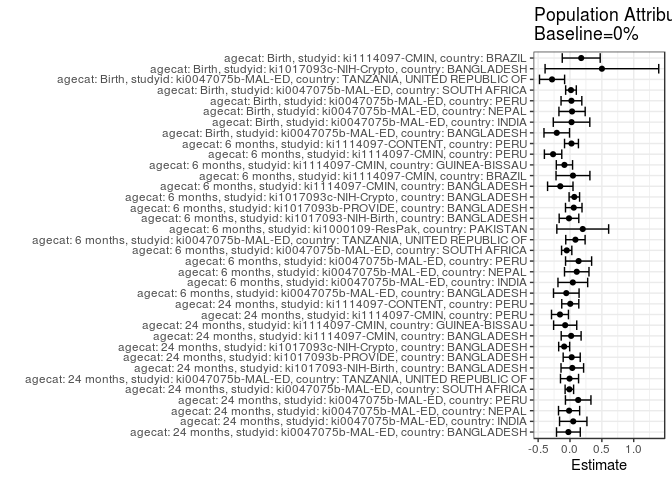

## Results Table

### Parameter: TSM

| agecat | studyid | country | intervention_level | baseline_level | estimate | ci_lower | ci_upper |
| --- | --- | --- | --- | --- | --- | --- | --- |
| Birth | ki0047075b-MAL-ED | BANGLADESH | 0% | NA | -0.7553165 | -1.0070322 | -0.5036007 |
| Birth | ki0047075b-MAL-ED | BANGLADESH | (0%, 5%] | NA | -1.1023913 | -1.3069020 | -0.8978806 |
| Birth | ki0047075b-MAL-ED | BANGLADESH | >5% | NA | -1.0144286 | -1.2625193 | -0.7663378 |
| Birth | ki0047075b-MAL-ED | INDIA | 0% | NA | -1.0934783 | -1.4326624 | -0.7542941 |
| Birth | ki0047075b-MAL-ED | INDIA | (0%, 5%] | NA | -1.0797196 | -1.2547563 | -0.9046830 |
| Birth | ki0047075b-MAL-ED | INDIA | >5% | NA | -1.0240000 | -1.3058361 | -0.7421639 |
| Birth | ki0047075b-MAL-ED | NEPAL | 0% | NA | -0.9367857 | -1.1993735 | -0.6741980 |
| Birth | ki0047075b-MAL-ED | NEPAL | (0%, 5%] | NA | -0.8745614 | -1.0864202 | -0.6627026 |
| Birth | ki0047075b-MAL-ED | NEPAL | >5% | NA | -0.9025455 | -1.1509786 | -0.6541123 |
| Birth | ki0047075b-MAL-ED | PERU | 0% | NA | -0.0960976 | -0.2833556 | 0.0911605 |
| Birth | ki0047075b-MAL-ED | PERU | (0%, 5%] | NA | 0.0436905 | -0.1751074 | 0.2624883 |
| Birth | ki0047075b-MAL-ED | PERU | >5% | NA | -0.1444248 | -0.3128279 | 0.0239783 |
| Birth | ki0047075b-MAL-ED | SOUTH AFRICA | 0% | NA | -0.0568750 | -0.2178610 | 0.1041110 |
| Birth | ki0047075b-MAL-ED | SOUTH AFRICA | (0%, 5%] | NA | 0.0457143 | -0.2756394 | 0.3670679 |
| Birth | ki0047075b-MAL-ED | SOUTH AFRICA | >5% | NA | -0.1888889 | -1.3021928 | 0.9244150 |
| Birth | ki0047075b-MAL-ED | TANZANIA, UNITED REPUBLIC OF | 0% | NA | 1.0749153 | 0.8307316 | 1.3190989 |
| Birth | ki0047075b-MAL-ED | TANZANIA, UNITED REPUBLIC OF | (0%, 5%] | NA | 0.2892500 | -0.0931801 | 0.6716801 |
| Birth | ki0047075b-MAL-ED | TANZANIA, UNITED REPUBLIC OF | >5% | NA | 0.9794737 | 0.6518306 | 1.3071168 |
| Birth | ki1017093c-NIH-Crypto | BANGLADESH | 0% | NA | -1.2516667 | -2.3338692 | -0.1694641 |
| Birth | ki1017093c-NIH-Crypto | BANGLADESH | (0%, 5%] | NA | -0.3185714 | -0.9422112 | 0.3050684 |
| Birth | ki1017093c-NIH-Crypto | BANGLADESH | >5% | NA | -0.7530000 | -1.4736153 | -0.0323847 |
| Birth | ki1114097-CMIN | BRAZIL | 0% | NA | -0.3094444 | -0.6642141 | 0.0453252 |
| Birth | ki1114097-CMIN | BRAZIL | (0%, 5%] | NA | -0.1182609 | -0.4107454 | 0.1742237 |
| Birth | ki1114097-CMIN | BRAZIL | >5% | NA | 0.0617241 | -0.4198596 | 0.5433079 |
| 6 months | ki0047075b-MAL-ED | BANGLADESH | 0% | NA | -0.0815728 | -0.3212509 | 0.1581054 |
| 6 months | ki0047075b-MAL-ED | BANGLADESH | (0%, 5%] | NA | -0.2727264 | -0.4832735 | -0.0621794 |
| 6 months | ki0047075b-MAL-ED | BANGLADESH | >5% | NA | -0.0360043 | -0.2552216 | 0.1832131 |
| 6 months | ki0047075b-MAL-ED | INDIA | 0% | NA | -0.7477667 | -1.0068715 | -0.4886618 |
| 6 months | ki0047075b-MAL-ED | INDIA | (0%, 5%] | NA | -0.6904068 | -0.8442239 | -0.5365897 |
| 6 months | ki0047075b-MAL-ED | INDIA | >5% | NA | -0.6937571 | -0.9979712 | -0.3895429 |

[output cut: 78 more lines]

### Parameter: E(Y)

| agecat | studyid | country | intervention_level | baseline_level | estimate | ci_lower | ci_upper |
| --- | --- | --- | --- | --- | --- | --- | --- |
| Birth | ki0047075b-MAL-ED | BANGLADESH | NA | NA | -0.9630705 | -1.0989132 | -0.8272278 |
| Birth | ki0047075b-MAL-ED | INDIA | NA | NA | -1.0691133 | -1.2078629 | -0.9303637 |
| Birth | ki0047075b-MAL-ED | NEPAL | NA | NA | -0.9044643 | -1.0439568 | -0.7649718 |
| Birth | ki0047075b-MAL-ED | PERU | NA | NA | -0.0735842 | -0.1836203 | 0.0364518 |
| Birth | ki0047075b-MAL-ED | SOUTH AFRICA | NA | NA | -0.0415200 | -0.1860797 | 0.1030397 |
| Birth | ki0047075b-MAL-ED | TANZANIA, UNITED REPUBLIC OF | NA | NA | 0.7932203 | 0.5962220 | 0.9902187 |
| Birth | ki1017093c-NIH-Crypto | BANGLADESH | NA | NA | -0.7508696 | -1.2358912 | -0.2658480 |
| Birth | ki1114097-CMIN | BRAZIL | NA | NA | -0.1332432 | -0.3441055 | 0.0776190 |
| 6 months | ki0047075b-MAL-ED | BANGLADESH | NA | NA | -0.1397960 | -0.2688682 | -0.0107238 |
| 6 months | ki0047075b-MAL-ED | INDIA | NA | NA | -0.7033969 | -0.8285284 | -0.5782654 |
| 6 months | ki0047075b-MAL-ED | NEPAL | NA | NA | 0.1110452 | -0.0202712 | 0.2423616 |
| 6 months | ki0047075b-MAL-ED | PERU | NA | NA | 1.0543956 | 0.9326967 | 1.1760945 |
| 6 months | ki0047075b-MAL-ED | SOUTH AFRICA | NA | NA | 0.5420735 | 0.3899459 | 0.6942011 |
| 6 months | ki0047075b-MAL-ED | TANZANIA, UNITED REPUBLIC OF | NA | NA | 0.5170513 | 0.3872178 | 0.6468847 |
| 6 months | ki1000109-ResPak | PAKISTAN | NA | NA | -0.1683617 | -0.3528233 | 0.0160999 |
| 6 months | ki1017093-NIH-Birth | BANGLADESH | NA | NA | -0.4389101 | -0.5279432 | -0.3498771 |
| 6 months | ki1017093b-PROVIDE | BANGLADESH | NA | NA | -0.2083706 | -0.2927992 | -0.1239419 |
| 6 months | ki1017093c-NIH-Crypto | BANGLADESH | NA | NA | 0.0297622 | -0.0491685 | 0.1086930 |
| 6 months | ki1114097-CMIN | BANGLADESH | NA | NA | -0.5780453 | -0.7226627 | -0.4334279 |
| 6 months | ki1114097-CMIN | BRAZIL | NA | NA | 0.5889815 | 0.3767666 | 0.8011963 |
| 6 months | ki1114097-CMIN | GUINEA-BISSAU | NA | NA | -0.0832589 | -0.1713269 | 0.0048090 |
| 6 months | ki1114097-CMIN | PERU | NA | NA | 0.6708938 | 0.5815040 | 0.7602836 |
| 6 months | ki1114097-CONTENT | PERU | NA | NA | 1.0684318 | 0.9515274 | 1.1853362 |
| 24 months | ki0047075b-MAL-ED | BANGLADESH | NA | NA | -0.8208255 | -0.9429246 | -0.6987264 |
| 24 months | ki0047075b-MAL-ED | INDIA | NA | NA | -0.9522907 | -1.0676596 | -0.8369219 |
| 24 months | ki0047075b-MAL-ED | NEPAL | NA | NA | -0.3764474 | -0.4898516 | -0.2630431 |
| 24 months | ki0047075b-MAL-ED | PERU | NA | NA | 0.1199005 | -0.0000331 | 0.2398341 |
| 24 months | ki0047075b-MAL-ED | SOUTH AFRICA | NA | NA | 0.4267017 | 0.3074751 | 0.5459283 |
| 24 months | ki0047075b-MAL-ED | TANZANIA, UNITED REPUBLIC OF | NA | NA | 0.0500935 | -0.0748234 | 0.1750103 |
| 24 months | ki1017093-NIH-Birth | BANGLADESH | NA | NA | -0.9115790 | -1.0095022 | -0.8136559 |
| 24 months | ki1017093b-PROVIDE | BANGLADESH | NA | NA | -0.8879412 | -0.9708680 | -0.8050144 |
| 24 months | ki1017093c-NIH-Crypto | BANGLADESH | NA | NA | -0.6103502 | -0.7050157 | -0.5156847 |
| 24 months | ki1114097-CMIN | BANGLADESH | NA | NA | -0.8535391 | -0.9644236 | -0.7426546 |
| 24 months | ki1114097-CMIN | GUINEA-BISSAU | NA | NA | -0.2053345 | -0.3365972 | -0.0740718 |
| 24 months | ki1114097-CMIN | PERU | NA | NA | 0.7958060 | 0.6890764 | 0.9025356 |
| 24 months | ki1114097-CONTENT | PERU | NA | NA | 0.5668293 | 0.4302437 | 0.7034148 |

### Parameter: ATE

| agecat | studyid | country | intervention_level | baseline_level | estimate | ci_lower | ci_upper |
| --- | --- | --- | --- | --- | --- | --- | --- |
| Birth | ki0047075b-MAL-ED | BANGLADESH | 0% | 0% | 0.0000000 | 0.0000000 | 0.0000000 |
| Birth | ki0047075b-MAL-ED | BANGLADESH | (0%, 5%] | 0% | -0.3470748 | -0.6713979 | -0.0227518 |
| Birth | ki0047075b-MAL-ED | BANGLADESH | >5% | 0% | -0.2591121 | -0.6125380 | 0.0943137 |
| Birth | ki0047075b-MAL-ED | INDIA | 0% | 0% | 0.0000000 | 0.0000000 | 0.0000000 |
| Birth | ki0047075b-MAL-ED | INDIA | (0%, 5%] | 0% | 0.0137586 | -0.3679268 | 0.3954440 |
| Birth | ki0047075b-MAL-ED | INDIA | >5% | 0% | 0.0694783 | -0.3715178 | 0.5104743 |
| Birth | ki0047075b-MAL-ED | NEPAL | 0% | 0% | 0.0000000 | 0.0000000 | 0.0000000 |
| Birth | ki0047075b-MAL-ED | NEPAL | (0%, 5%] | 0% | 0.0622243 | -0.2751723 | 0.3996209 |
| Birth | ki0047075b-MAL-ED | NEPAL | >5% | 0% | 0.0342403 | -0.3272447 | 0.3957252 |
| Birth | ki0047075b-MAL-ED | PERU | 0% | 0% | 0.0000000 | 0.0000000 | 0.0000000 |
| Birth | ki0047075b-MAL-ED | PERU | (0%, 5%] | 0% | 0.1397880 | -0.1482017 | 0.4277777 |
| Birth | ki0047075b-MAL-ED | PERU | >5% | 0% | -0.0483272 | -0.3001708 | 0.2035163 |
| Birth | ki0047075b-MAL-ED | SOUTH AFRICA | 0% | 0% | 0.0000000 | 0.0000000 | 0.0000000 |
| Birth | ki0047075b-MAL-ED | SOUTH AFRICA | (0%, 5%] | 0% | 0.1025893 | -0.2568334 | 0.4620120 |
| Birth | ki0047075b-MAL-ED | SOUTH AFRICA | >5% | 0% | -0.1320139 | -1.2568970 | 0.9928693 |
| Birth | ki0047075b-MAL-ED | TANZANIA, UNITED REPUBLIC OF | 0% | 0% | 0.0000000 | 0.0000000 | 0.0000000 |
| Birth | ki0047075b-MAL-ED | TANZANIA, UNITED REPUBLIC OF | (0%, 5%] | 0% | -0.7856653 | -1.2394035 | -0.3319270 |
| Birth | ki0047075b-MAL-ED | TANZANIA, UNITED REPUBLIC OF | >5% | 0% | -0.0954416 | -0.5040682 | 0.3131850 |
| Birth | ki1017093c-NIH-Crypto | BANGLADESH | 0% | 0% | 0.0000000 | 0.0000000 | 0.0000000 |
| Birth | ki1017093c-NIH-Crypto | BANGLADESH | (0%, 5%] | 0% | 0.9330952 | -0.3159400 | 2.1821305 |
| Birth | ki1017093c-NIH-Crypto | BANGLADESH | >5% | 0% | 0.4986667 | -0.8015059 | 1.7988393 |
| Birth | ki1114097-CMIN | BRAZIL | 0% | 0% | 0.0000000 | 0.0000000 | 0.0000000 |
| Birth | ki1114097-CMIN | BRAZIL | (0%, 5%] | 0% | 0.1911836 | -0.2686085 | 0.6509756 |
| Birth | ki1114097-CMIN | BRAZIL | >5% | 0% | 0.3711686 | -0.2269822 | 0.9693194 |
| 6 months | ki0047075b-MAL-ED | BANGLADESH | 0% | 0% | 0.0000000 | 0.0000000 | 0.0000000 |
| 6 months | ki0047075b-MAL-ED | BANGLADESH | (0%, 5%] | 0% | -0.1911537 | -0.5101767 | 0.1278693 |
| 6 months | ki0047075b-MAL-ED | BANGLADESH | >5% | 0% | 0.0455685 | -0.2792420 | 0.3703790 |
| 6 months | ki0047075b-MAL-ED | INDIA | 0% | 0% | 0.0000000 | 0.0000000 | 0.0000000 |
| 6 months | ki0047075b-MAL-ED | INDIA | (0%, 5%] | 0% | 0.0573598 | -0.2439622 | 0.3586819 |
| 6 months | ki0047075b-MAL-ED | INDIA | >5% | 0% | 0.0540096 | -0.3455921 | 0.4536114 |

[output cut: 78 more lines]

### Parameter: PAR

| agecat | studyid | country | intervention_level | baseline_level | estimate | ci_lower | ci_upper |
| --- | --- | --- | --- | --- | --- | --- | --- |
| Birth | ki0047075b-MAL-ED | BANGLADESH | 0% | NA | -0.2077541 | -0.4084394 | -0.0070688 |
| Birth | ki0047075b-MAL-ED | INDIA | 0% | NA | 0.0243650 | -0.2622678 | 0.3109977 |
| Birth | ki0047075b-MAL-ED | NEPAL | 0% | NA | 0.0323214 | -0.1736938 | 0.2383366 |
| Birth | ki0047075b-MAL-ED | PERU | 0% | NA | 0.0225133 | -0.1404636 | 0.1854903 |
| Birth | ki0047075b-MAL-ED | SOUTH AFRICA | 0% | NA | 0.0153550 | -0.0683484 | 0.0990584 |
| Birth | ki0047075b-MAL-ED | TANZANIA, UNITED REPUBLIC OF | 0% | NA | -0.2816949 | -0.4786933 | -0.0846966 |
| Birth | ki1017093c-NIH-Crypto | BANGLADESH | 0% | NA | 0.5007971 | -0.3910365 | 1.3926307 |
| Birth | ki1114097-CMIN | BRAZIL | 0% | NA | 0.1762012 | -0.1215982 | 0.4740007 |
| 6 months | ki0047075b-MAL-ED | BANGLADESH | 0% | NA | -0.0582232 | -0.2588662 | 0.1424198 |
| 6 months | ki0047075b-MAL-ED | INDIA | 0% | NA | 0.0443698 | -0.1887526 | 0.2774922 |
| 6 months | ki0047075b-MAL-ED | NEPAL | 0% | NA | 0.1058577 | -0.0862458 | 0.2979612 |
| 6 months | ki0047075b-MAL-ED | PERU | 0% | NA | 0.1348368 | -0.0697761 | 0.3394497 |
| 6 months | ki0047075b-MAL-ED | SOUTH AFRICA | 0% | NA | -0.0517423 | -0.1321802 | 0.0286956 |
| 6 months | ki0047075b-MAL-ED | TANZANIA, UNITED REPUBLIC OF | 0% | NA | 0.0851465 | -0.0667453 | 0.2370383 |
| 6 months | ki1000109-ResPak | PAKISTAN | 0% | NA | 0.1999310 | -0.2066994 | 0.6065614 |
| 6 months | ki1017093-NIH-Birth | BANGLADESH | 0% | NA | -0.0160032 | -0.1700317 | 0.1380254 |
| 6 months | ki1017093b-PROVIDE | BANGLADESH | 0% | NA | 0.0589543 | -0.0706265 | 0.1885350 |
| 6 months | ki1017093c-NIH-Crypto | BANGLADESH | 0% | NA | 0.0680027 | -0.0144345 | 0.1504399 |
| 6 months | ki1114097-CMIN | BANGLADESH | 0% | NA | -0.1524074 | -0.3519488 | 0.0471340 |
| 6 months | ki1114097-CMIN | BRAZIL | 0% | NA | 0.0466131 | -0.2192084 | 0.3124345 |
| 6 months | ki1114097-CMIN | GUINEA-BISSAU | 0% | NA | -0.0872448 | -0.2148968 | 0.0404073 |
| 6 months | ki1114097-CMIN | PERU | 0% | NA | -0.2655011 | -0.4018901 | -0.1291122 |
| 6 months | ki1114097-CONTENT | PERU | 0% | NA | 0.0233550 | -0.0856985 | 0.1324084 |
| 24 months | ki0047075b-MAL-ED | BANGLADESH | 0% | NA | -0.0252005 | -0.2116903 | 0.1612894 |
| 24 months | ki0047075b-MAL-ED | INDIA | 0% | NA | 0.0508343 | -0.1640329 | 0.2657014 |
| 24 months | ki0047075b-MAL-ED | NEPAL | 0% | NA | -0.0143694 | -0.1802843 | 0.1515454 |
| 24 months | ki0047075b-MAL-ED | PERU | 0% | NA | 0.1285797 | -0.0716172 | 0.3287766 |
| 24 months | ki0047075b-MAL-ED | SOUTH AFRICA | 0% | NA | -0.0100215 | -0.0767124 | 0.0566694 |
| 24 months | ki0047075b-MAL-ED | TANZANIA, UNITED REPUBLIC OF | 0% | NA | -0.0073522 | -0.1491495 | 0.1344451 |
| 24 months | ki1017093-NIH-Birth | BANGLADESH | 0% | NA | 0.0362558 | -0.1410196 | 0.2135313 |
| 24 months | ki1017093b-PROVIDE | BANGLADESH | 0% | NA | 0.0265983 | -0.1071326 | 0.1603292 |
| 24 months | ki1017093c-NIH-Crypto | BANGLADESH | 0% | NA | -0.0914332 | -0.1776713 | -0.0051951 |
| 24 months | ki1114097-CMIN | BANGLADESH | 0% | NA | 0.0180491 | -0.1381622 | 0.1742604 |
| 24 months | ki1114097-CMIN | GUINEA-BISSAU | 0% | NA | -0.0756881 | -0.2572249 | 0.1058487 |
| 24 months | ki1114097-CMIN | PERU | 0% | NA | -0.1572524 | -0.2901909 | -0.0243139 |
| 24 months | ki1114097-CONTENT | PERU | 0% | NA | 0.0042697 | -0.1295841 | 0.1381236 |